# Lab assignment 1 – Helen Hsu

In Lab 1, we combined subsetting, random sampling and for loop to simulate the probability of observing a head when flipping a fair coin. In Lab 1 assignment, we consider a more challenging problem: throwing two fair dices. In particular, we are interested in the probability of observing two dices with the same number.

# 0. Set seed

```r
set.seed(1234)
```

# 1. Theoretical results

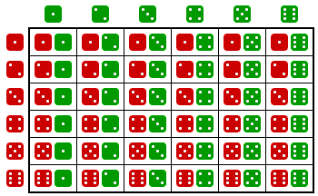

All possible outcomes from throwing two fair dices. The probability of observing each outcome is equally 1/36. (Picture found from internet)

As observed in the above figure, there are 6 situations out of 36 when we observe two dices with the same number. If the two dices are both fair and the outcomes from the two dices are independent, the probability of rolling doubles is 6/36 = 1/6 $\approx$ 0.167.

# 2. Simulation

Let us throw the two dices for ten times.

**[1 points]** Draw 10 numbers with equal probability from 1,2,3,4,5,6 (representing a die), with replacement. This represents the numbers observed from the first die.

```r
firstdice <- sample(c(1,2,3,4,5,6), size=10, replace=T)
firstdice
```

```
##  [1] 4 2 6 5 4 1 5 6 4 2
```

**[1 points]** Again, draw 10 numbers with equal probability from 1,2,3,4,5,6 with replacement. This represents the numbers observed from the second die.

```r
seconddice <- sample(c(1,2,3,4,5,6), size=10, replace=T)
seconddice
```

```
##  [1] 6 2 6 6 4 6 6 6 4 4
```

**[1 points]** For the 4th observation out of the 10 outcomes, use relational operators to show whether a double is observed.

```r
firstdice[4]==seconddice[4]
```

```
## [1] FALSE
```

**[2 points]** Obtain the proportion of doubles out of the 10 observations

```r
n <- 10
n.matches <- 0

for (i in 1:10) {
  if (firstdice[i]==seconddice[i]) {
    n.matches <- n.matches + 1
  }
}
n.matches/n
```

```
## [1] 0.5
```

**[2 points]** Now assuming throwing the two dices for 100 times. Repeat the previous simulation and report the proportion of doubles out of the 100 simulated observations.

```r
n <- 100
n.matches <- 0
firstdice <- sample(c(1,2,3,4,5,6), size=n, replace=T)
seconddice <- sample(c(1,2,3,4,5,6), size=n, replace=T)
for (i in 1:n) {
  if (firstdice[i]==seconddice[i]) {
    n.matches <- n.matches + 1
  }
}
n.matches/n
```

```
## [1] 0.16
```

**[3 points]** Repeat the previous simulation when the two dices are thrown N times, from your choices of N:

```r
N <- 1000
n.matches <- 0
firstdice <- sample(c(1,2,3,4,5,6), size=N, replace=T)
seconddice <- sample(c(1,2,3,4,5,6), size=N, replace=T)
for (i in 1:N) {
  if (firstdice[i]==seconddice[i]) {
    n.matches <- n.matches + 1
  }
}
n.matches/N
```

```
## [1] 0.152
```

Plot the proportion of doubles versus N, with theoretical probability plotted as a horizontal line.

```r
set.seed(1234)
N <- c(10,25,50,100,250,500,1000,2500,5000)
length(N)
```

```
## [1] 9
```

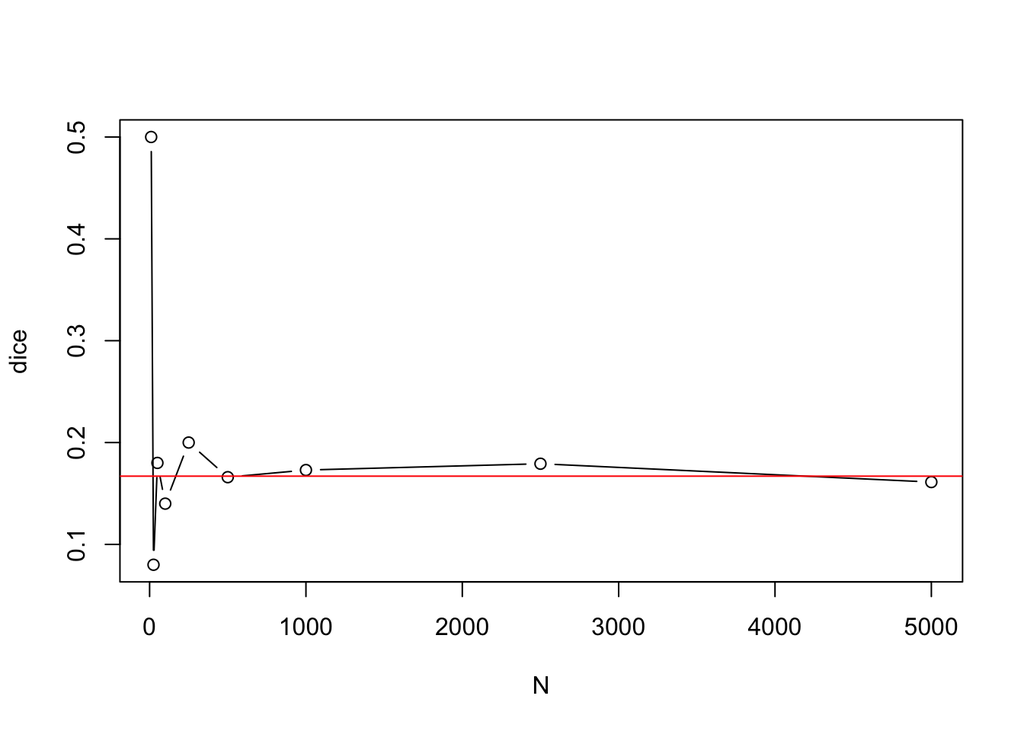

```r
dice <- rep(0,9)
for(i in 1:9) {
  n.matches <- 0
  firstdice <- sample(c(1,2,3,4,5,6), size=N[i], replace=T)
  seconddice <- sample(c(1,2,3,4,5,6), size=N[i], replace=T)
  for (j in 1:N[i]) {
  if (firstdice[j]==seconddice[j]) {
    n.matches <- n.matches + 1
    dice[i] <- n.matches/N[i]
    }
  }
}
plot(N,dice,type='b',col='black')
abline(h=0.167,col='red')
```